# HW 3

## 2.4

Above we have a fully grown (bushy) tree. Now, cross validate it using the `cv.tree` command. Specify cross validation to be done according to the misclassification rate. Choose an ideal number of splits, and plot this tree. Finally, use this pruned tree to test on the testing set. Report a confusion matrix and the misclassification rate.

```r
set.seed(101)
cv.heart <- cv.tree(heart.tree, FUN = prune.misclass)
cv.heart
```

```
## $size
## [1] 19 15 12 11  7  6  4  2  1
##
## $dev
## [1]  65  64  64  59  56  56  53  53 116
##
## $k
## [1]       -Inf  0.0000000  0.6666667  1.0000000  1.5000000  2.0000000  3.5000000
## [8]  5.5000000 63.0000000
##
## $method
## [1] "misclass"
##
## attr(,"class")
## [1] "prune"         "tree.sequence"
```

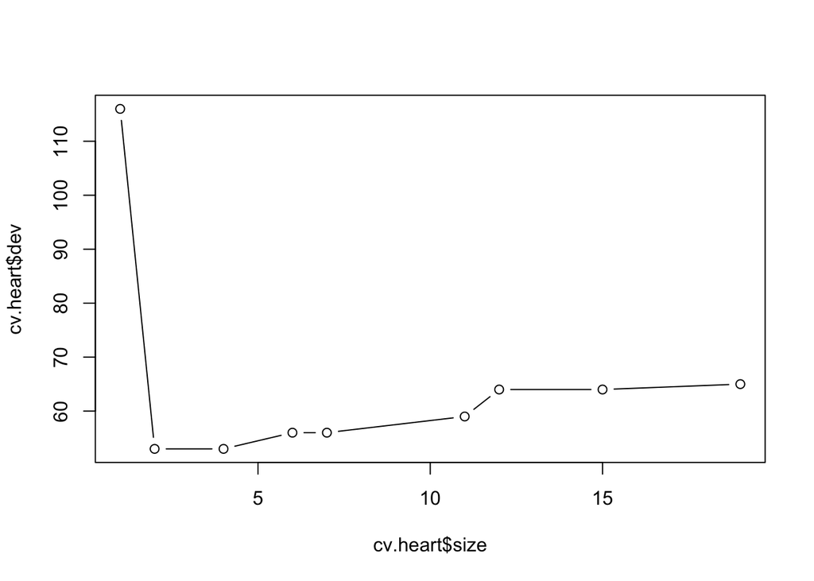

```r
# Best choice is 2 splits
plot(cv.heart$size, cv.heart$dev, type = "b")
```

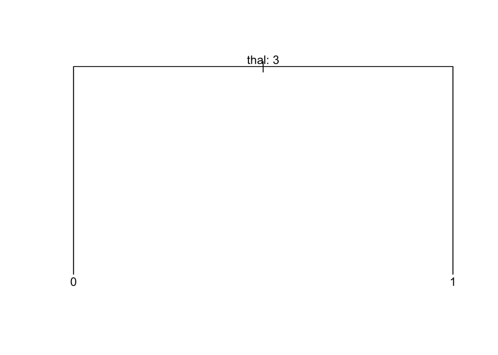

```r
prune.heart = prune.misclass(heart.tree, best = 2)

plot(prune.heart)
text(prune.heart, pretty=0)
```

```r
tree.pred = predict(prune.heart, heart_data[-train_ran,], type="class")
with(heart_data[-train_ran,], table(tree.pred, heart_disease))
```

```
##          heart_disease
## tree.pred  0  1
##         0 28  9
##         1  8 12
```

```r
# Misclassification rate:
(8+9)/(28+9+8+12)
```

```
## [1] 0.2982456
```

## 2.5

Discuss the trade-off in accuracy and interpretability in pruning the above tree.

Pruning the above tree improves interpretability, but it also increases the misclassification rate. However, the vast improvement in interpretability is a good trade off for a small decrease in accuracy. The original bushy tree was barely even readable! A bushy tree that is overfit can also result in a non generalizable tree for testing or other datasets.

## 2.6

Discuss the ways a decision tree could manifest algorithmic bias.

If the training dataset reflects prejudices or if certain classes are underrepresented, algorithmic bias may manifest when training a model. Since the premise of decision trees is classifying using labels that separate the data well, algorithmic bias can manifest when all observations under a particular class label are split off into their own subtree, which may amplify existing bias in the data. When the model is used on testing datasets, classes that are not well represented in the training data might have particularly high misclassification rates, disproportionate to other classes that are well represented.

[^1]: Remember this is a parameter that decides how smooth your decision boundary should be